# Generating Animated GIFs and plots for NFL Tracking data using ggplot

Pablo Landeros

2022-10-21

This is meant to be a very simple implementation of a collection of functions to plot frames and animate the tracking data housed in the [Big Data Bowl Kaggle Competition](https://www.kaggle.com/competitions/nfl-big-data-bowl-2023/data).

## Credits

All of the codes were based on `asonty`’s `ngs_highlights` repo. Check out his work [here](https://github.com/asonty/ngs_highlights)!

## Important Note

If you want to use theses functions locally, you should first download the competition data and place it in a folder called `data` within your **home directory**.

## Generating the plot

To generate a play animation, head to the `src.R` script, change the `playId_` and `gameId_` parameters and run the script.

# Code Breakdown

### Setup

```r
# * Load libraries ----
library(gganimate)
library(tidyverse)
```

Based on user **asonty**’s work, I coded helper functions to extract and plot data.

```r
# * Load helper functions ----
source("utils/plot_utils.R")
source("utils/data_utils.R")
```

### Read data

Because of the size of the files, I did not include the data directory in this repository. Nevertheless, you can download the data from [Kaggle](https://www.kaggle.com/competitions/nfl-big-data-bowl-2023/data) and place it in a folder called `data` within the home directory.

```r
# * read week 1 data ----
df <- read.csv("data/week1.csv")
```

### Parameters

Set the play which you want to plot and extract the info:

```r
playId_ = 137
gameId_ = 2021090900

play <- fetch_play(df, playId_, gameId_)
```

#### Plot a single frame

You can plot a specific frame of a play by using the `plot_frame` function.

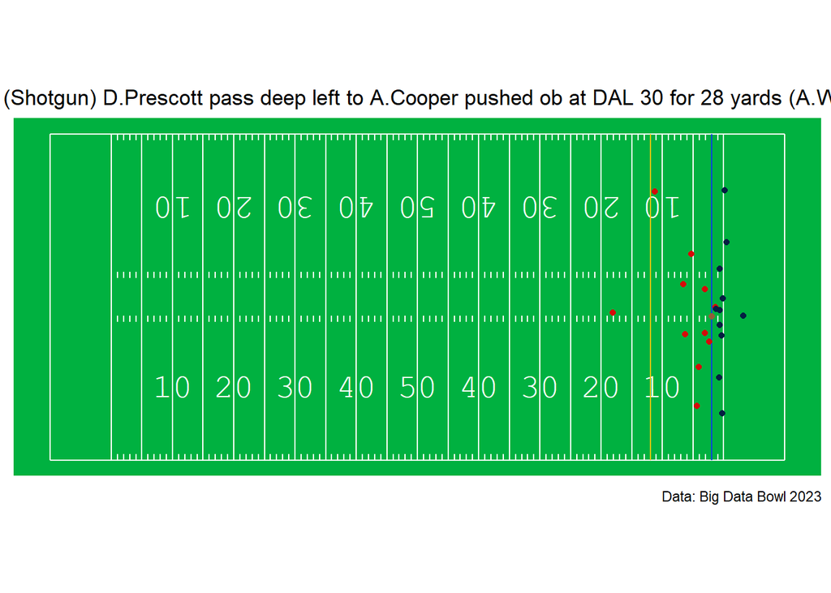

```r
plot_frame(play,1)
```

#### Generate an animated gif of a play

```r
play_length <- length(unique(play$frameId))
# customize duration of gif
duration_ = 7
# Animate our play! :D
animate(
  play_animation(play),
  duration = 7,
  fps = 10,
  nframe = play_length,
  width = 850,
  height = 500,
  end_pause = 10
)
```

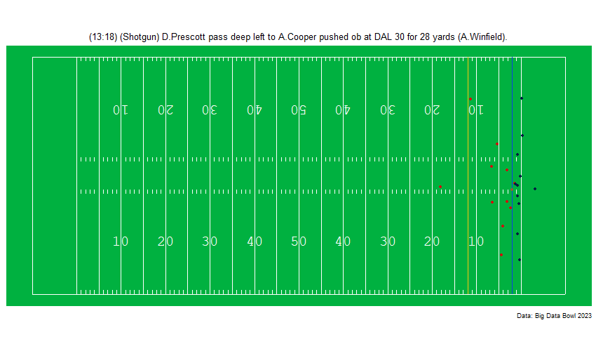